# Lab_4

Heather M

10/7/2020

```r
library(readxl)
library(dplyr)
library(tidyverse)
```

```r
library(ggplot2)
defense <- read_excel('cyclonesFootball2019.xlsx' ,sheet = 'Defensive')
offense <- read_excel("cyclonesFootball2019.xlsx", sheet = 'Offensive')
biography <- read_excel("cyclonesFootball2019.xlsx", sheet = 'Biography')
```

Part one: Cleaning data Although the three Excel sheets are loaded into R, they are not useful before some cleaning. Manipulate the three imported data frames, so that in the cleaned dataset: 1.) The player names and opponent names are factors.

```r
defClean <- defense
Opponents <- defense$Opponent_Opponent
players <- defense$Name
teams <-factor(c(Opponents))
player <- factor(c(players))
defClean['Name'] <- player
defClean['Opponent_Opponent'] <- teams
```

2.) All offensive and defensive statistics are numerical. The Weight column in biography is also numeric. (Optional: Learn to mutate multiple columns systematically using the ?across function in `dplyr)

```r
OffClean <- offense

def_a <- subset(defense,select = c('Tackles_Solo', 'Tackles_ASST', 'Tackles_Sack', 'Tackles_TFL','Turnover_FF', 'Turnover_FR', 'Turnover_INT', 'Pass_QBH', 'Pass_PB' ))

def_b <-subset(defense, select = c('Name', 'Opponent_Opponent'))


off_a <- subset(OffClean, select = c('Rushing_ATT', 'Rushing_YDS', 'Rushing_TD', 'Receiving_REC', 'Receiving_YDS', 'Receiving_TD', 'Passing_CMP-ATT', 'Passing_YDS', 'Passing_TD', 'Passing_INT'))

off_b <- subset(offense, select = c('Name', 'Opponent_Opponent'))


defClean <- def_a %>% mutate_if(is.character, as.numeric)

OffClean <- off_a %>% mutate_if(is.character, as.numeric)
```

```r
defClean$Name <- def_b$Name
defClean$Opponent <- def_b$Opponent_Opponent

OffClean$Name <- off_b$Name
OffClean$opponent <- off_b$Opponent_Opponent

BioClean <- biography
BioClean['Weight'] <- as.numeric(c(BioClean$Weight))
```

3.)Change the Height column in biography into numeric. (Hint: Use a unit that works well

```r
BioClean <- biography %>% separate(Height, c('Feet', 'Inches'), sep = '-')

BioClean['Feet'] <- as.numeric(c(BioClean$Feet))
BioClean['Feet'] <- BioClean['Feet']*12

BioClean['Inches'] <- as.numeric(c(BioClean$Inches))

Height <- BioClean['Feet'] + BioClean['Inches']
BioClean <- subset(BioClean, select = -c(Inches , Feet))
```

#By cleaning the three data frames in R, at the end of this step you should have the following three clean data frames: defClean, offClean, and bioClean. Print the structures of these data frames.

```r
str(defClean)
```

```
## tibble [502 x 11] (S3: tbl_df/tbl/data.frame)
##  $ Tackles_Solo: num [1:502] 4 4 3 4 3 1 7 3 6 5 ...
##  $ Tackles_ASST: num [1:502] 4 7 5 2 2 1 1 2 1 5 ...
##  $ Tackles_Sack: num [1:502] 0 0 0 0 0 0 0 0 0 1 ...
##  $ Tackles_TFL : num [1:502] 0 0 0 0 1 0 0 0 1 1 ...
##  $ Turnover_FF : num [1:502] 0 0 0 0 0 0 0 0 0 0 ...
##  $ Turnover_FR : num [1:502] 0 0 0 0 0 0 0 0 0 0 ...
##  $ Turnover_INT: num [1:502] 0 0 1 0 0 0 0 0 1 0 ...
##  $ Pass_QBH    : num [1:502] 1 0 0 0 0 0 0 0 1 0 ...
##  $ Pass_PB     : num [1:502] 1 2 0 0 0 1 0 0 0 0 ...
##  $ Name        : chr [1:502] "White, Lawrence" "White, Lawrence" "White, Lawrence" "White, Lawrence" ...
##  $ Opponent    : chr [1:502] "UNI" "Iowa" "ULM" "Baylor" ...
```

```r
str(OffClean)
```

```
## tibble [195 x 12] (S3: tbl_df/tbl/data.frame)
##  $ Rushing_ATT    : num [1:195] 0 0 1 0 0 0 0 0 0 0 ...
##  $ Rushing_YDS    : num [1:195] 0 0 8 0 0 0 0 0 0 0 ...
##  $ Rushing_TD     : num [1:195] 0 0 0 0 0 0 0 0 0 0 ...
##  $ Receiving_REC  : num [1:195] 1 0 0 0 1 0 0 4 0 1 ...
##  $ Receiving_YDS  : num [1:195] 21 0 0 0 32 0 0 39 0 7 ...
##  $ Receiving_TD   : num [1:195] 0 0 0 0 0 0 0 0 0 0 ...
##  $ Passing_CMP-ATT: num [1:195] NA NA NA NA NA NA NA NA NA NA ...
##  $ Passing_YDS    : num [1:195] NA NA NA NA NA NA NA NA NA NA ...
##  $ Passing_TD     : num [1:195] NA NA NA NA NA NA NA NA NA NA ...
##  $ Passing_INT    : num [1:195] NA NA NA NA NA NA NA NA NA NA ...
##  $ Name           : chr [1:195] "Akers, Landen" "Akers, Landen" "Akers, Landen" "Akers, Landen" ...
##  $ opponent       : chr [1:195] "UNI" "Iowa" "ULM" "Baylor" ...
```

```r
str(BioClean)
```

```
## tibble [105 x 6] (S3: tbl_df/tbl/data.frame)
##  $ Name      : chr [1:105] "Akers, Landen" "Allen, Chase" "Anderson, Ezeriah" "Assalley, Connor" ...
##  $ Position  : chr [1:105] "Wide Receiver" "Tight End" "Wide Receiver" "Placekicker" ...
##  $ Weight    : chr [1:105] "188" "245" "204" "195" ...
##  $ Class     : chr [1:105] "Redshirt Senior" "Redshirt Senior" "Redshirt Freshman" "Redshirt Senior" ...
##  $ Hometown  : chr [1:105] "Cedar Rapids, Iowa" "Nixa, Mo." "Seffner, Fla." "Naperville, Ill." ...
##  $ Highschool: chr [1:105] "Washington" "Nixa" "Armwood" "Central" ...
```

*Part 2*

For the following questions, work on the cleaned data frames defClean, offClean, and bioClean.

1.)Reformat the defClean data frame into a tidy format using pivot_longer. The type of statistic (Tackles_Solo, Tackles_ASST, etc) is added as a new key column named stat.

```r
defClean_a <- defClean %>% pivot_longer(cols = starts_with('Tackles'),names_to = 'Tackles_Stats', values_to = 'count')
```

2.)Compare the distributions of the defensive statistics. What defensive skills are rare?

```r
defClean_a['Tackle_Stats'] <-  as.numeric(defClean_a$Tackles_Stats)
```

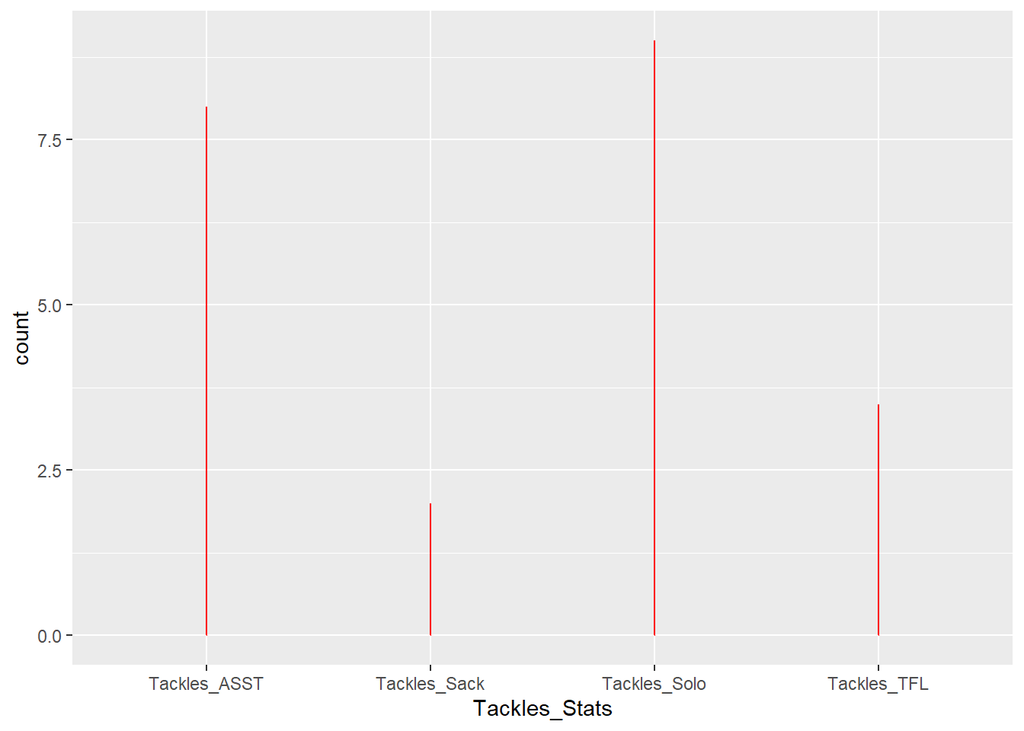

```r
ggplot(defClean_a, aes(x=Tackles_Stats, y=count)) + geom_line(color='red')
```

Based the visual representation above, it appears, from Tackle statistics, the most rare skill are sacks.